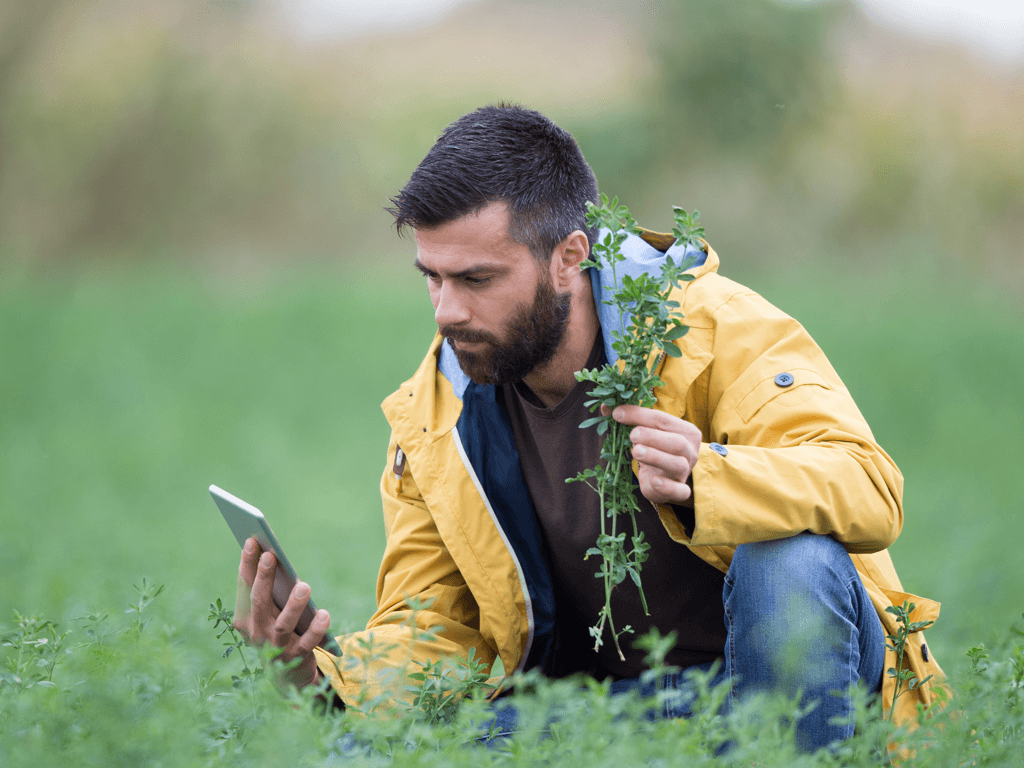

# Acte 9la blockchain alimentaire

# Généraliser la blockchain aux Filières Qualité CarrefourCette innovation technologique garantit une traçabilité sécurisée et infalsifiable des produits.

La blockchain alimentaire, c’est quoi au juste ?

La blockchain est une technologie de stockage et de transmission numérique d’informations sécurisées et infalsifiables. Elle constitue une base de données qui contient l’historique de tous les échanges effectués entre ses utilisateurs (producteurs, transformateurs et distributeurs) depuis sa création. Appliquée au secteur alimentaire, la blockchain permet de stocker les informations relatives au produit : sa provenance, son lieu d’élevage ou son mode de production. Elle garantit aux consommateurs une transparence complète sur le circuit suivi par les produits.

Pourquoi doit-on agir ?

Le consommateur désire toujours plus de transparence et d’assurances sur les produits qu’il achète. Nouer des relations de confiance avec le consommateur est nécessaire pour le producteur comme pour le distributeur. La blockchain alimentaire est une réponse à ce besoin du client. En scannant le QR code présent sur l’étiquette du produit, le consommateur peut accéder via son smartphone à des informations transparentes.

[figure not shown]

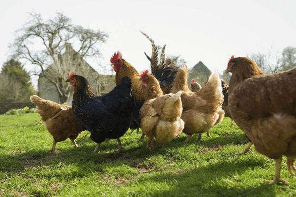

Le poulet d'Auvergne Filière Qualité Carrefour, premier produit qui intègre la technologie blockchain.

Est-ce vraiment si nouveau ?

La blockchain n’était pas jusqu’alors utilisée dans l’alimentaire. Carrefour est pionnier sur ce sujet en Europe avec la première application, en mars 2018, de la technologie blockchain au poulet d’Auvergne Filière Qualité Carrefour (FQC).

Quel est l’objectif sur la durée ?

En 2019, Carrefour a intégré progressivement la technologie blockchain aux Filières Qualité Carrefour suivantes: poulet d’Auvergne, tomate Cauralina, œufs fermiers de Loué, fromage rocamadour AOC, lait frais Gillot, saumon de Norvège et poularde de Noël. D’ici à 2022, l’objectif est d’appliquer cette technologie à tous les produits alimentaires FQC.

Objectif

2022 déploiement de la blockchain aux 100 FQC